# Course Project

## Introduction

In this project, we will use data from [Weight Lifting Exercise Dataset](http://groupware.les.inf.puc-rio.br/har), specifically, we will use accelerometers on the belt, forearm, arm, and dumbell of 6 participants.

The participants were asked to perform barbell lifts correctly and incorrectly in 5 different ways, then we will use the data to prediction the quality of the barbell lift exercise.

## Load the data

```r
library(Rmisc)
```

```r
library(ggplot2)
library(caret)

training_0 <- read.csv("pml-training.csv", na.strings=c("NA",""))
testing_0  <- read.csv("pml-testing.csv", na.strings=c("NA",""))
```

## Summary and data Exploratory

```r
# head(training_0)
# str(training_0)
dim(training_0)
```

```
## [1] 19622   160
```

```r
#names(training_0)
```

There are total 160 columns of data, we will do some data cleaning.

1. remove timestamp related columns.

```r
training_0  <- training_0[,7:160]
testing_0   <- testing_0[,7:160]
removeColumns <- grep("timestamp", names(training_0))
training_1 <- training_0[,-c(1, removeColumns )]
test_1 <- testing_0 [,-c(1, removeColumns )]
#names(training_1)
```

2. convert factor variabels to integers for correlation evaluations:

```r
classeLevels <- levels(training_1$classe)
training_2 <- data.frame(data.matrix(training_1))
training_2$classe <- factor(training_2$classe, labels=classeLevels)
test_2 <- data.frame(data.matrix(test_1))
```

3. Check some correlations between the columns

```r
classeIndex <- which(names(training_2) == "classe")
classeIndex
```

```
## [1] 153
```

```r
correlations <- cor(training_2[, -classeIndex], as.numeric(training_2$classe))
maxCorrelations <- subset(as.data.frame(as.table(correlations)), abs(Freq)>0.25)
maxCorrelations
```

```
##              Var1 Var2       Freq
## 37  magnet_belt_y    A -0.2903491
## 59   magnet_arm_x    A  0.2959636
## 60   magnet_arm_y    A -0.2566702
## 116 pitch_forearm    A  0.3438258
```

4. There is some correlation between the feature: “pitch_forearm” and “magnet_arm_y”, let’s plot them to visulize them:

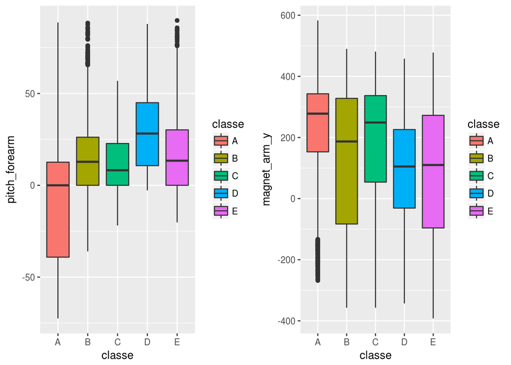

```r
p1 <- ggplot(training_2, aes(classe,pitch_forearm)) +
  geom_boxplot(aes(fill=classe))

p2 <- ggplot(training_2, aes(classe, magnet_arm_y)) +
  geom_boxplot(aes(fill=classe))

multiplot(p1,p2,cols=2)
```

## Clean the data

1. Remove the NA values:

```r
training_2 <- training_1[, colSums(is.na(training_1)) == 0]
testing_2  <- test_1[, colSums(is.na(test_1)) == 0]
dim(training_2)
```

```
## [1] 19622    53
```

2. Further slice the training data into test-validation test set:

```r
set.seed(334)
inTrain <- createDataPartition(training_2$classe, p=0.70, list=F)
trainData <- training_2[inTrain, ]
testData <- training_2[-inTrain, ]
dim(trainData)
```

```
## [1] 13737    53
```

Since there are many features, we will use Random Forest algorithm because it automatically selects most relavant features and is robust to correlated covariates & outliers in general. We will use 5-fold cross validation when applying the algorithm.

```r
library(randomForest)
rf_model <-train( classe ~ ., data=trainData, method="rf",
                 trControl=trainControl(method="cv",number=5),
                 prox=TRUE, allowParallel=TRUE)
print(rf_model)
```

```
## Random Forest
##
## 13737 samples
##    52 predictors
##     5 classes: 'A', 'B', 'C', 'D', 'E'
##
## No pre-processing
## Resampling: Cross-Validated (5 fold)
## Summary of sample sizes: 10990, 10990, 10990, 10989, 10989
## Resampling results across tuning parameters:
##
##   mtry  Accuracy   Kappa
##    2    0.9906822  0.9882128
##   27    0.9902455  0.9876609
##   52    0.9834029  0.9790025
##
## Accuracy was used to select the optimal model using the largest value.
## The final value used for the model was mtry = 2.
```

The final model is:

```r
print(rf_model$finalModel)
```

```
##
## Call:
##  randomForest(x = x, y = y, mtry = param$mtry, proximity = TRUE,      allowParallel = TRUE)
##                Type of random forest: classification
##                      Number of trees: 500
## No. of variables tried at each split: 2
##
##         OOB estimate of  error rate: 0.68%
## Confusion matrix:
##      A    B    C    D    E  class.error
## A 3903    3    0    0    0 0.0007680492
## B   12 2642    4    0    0 0.0060195636
## C    0   22 2374    0    0 0.0091819699
## D    0    0   42 2209    1 0.0190941385
## E    0    0    2    7 2516 0.0035643564
```

Now, we will test our final model on the testData:

```r
rf_predict <- predict(rf_model, testData)
confusionMatrix(testData$classe, rf_predict)
```

```
## Confusion Matrix and Statistics
##
##           Reference
## Prediction    A    B    C    D    E
##          A 1671    3    0    0    0
##          B    5 1128    6    0    0
##          C    0    3 1023    0    0
##          D    0    0   17  946    1
##          E    0    0    0    3 1079
##
## Overall Statistics
##
##                Accuracy : 0.9935
##                  95% CI : (0.9911, 0.9954)
##     No Information Rate : 0.2848
##     P-Value [Acc > NIR] : < 2.2e-16
##
##                   Kappa : 0.9918
##  Mcnemar's Test P-Value : NA
##
## Statistics by Class:
##
##                      Class: A Class: B Class: C Class: D Class: E
## Sensitivity            0.9970   0.9947   0.9780   0.9968   0.9991
## Specificity            0.9993   0.9977   0.9994   0.9964   0.9994
## Pos Pred Value         0.9982   0.9903   0.9971   0.9813   0.9972
## Neg Pred Value         0.9988   0.9987   0.9953   0.9994   0.9998
## Prevalence             0.2848   0.1927   0.1777   0.1613   0.1835
## Detection Rate         0.2839   0.1917   0.1738   0.1607   0.1833
## Detection Prevalence   0.2845   0.1935   0.1743   0.1638   0.1839
## Balanced Accuracy      0.9982   0.9962   0.9887   0.9966   0.9992
```

We can see that overall accuray for our predictions for the 5-classes are around 98% to 99%.

```r
rf_test_2 <- predict(rf_model, testing_2)
#rf_test_2
```

```r
# getTree(rf_model$finalModel, k=1)
```